# BCB420 Assignment 1

Dataset Selection and Initial Processing

Maryam Hasanzadehkiabi

2023-02-21

# 1. Dataset selection

## Insert required packages

<sup>1</sup><sup>2</sup> <sup>3</sup><sup>4</sup> <sup>5</sup><sup>6</sup> <sup>7</sup><sup>8</sup> <sup>9</sup><sup>10</sup> <sup>11</sup><sup>12</sup> <sup>13</sup><sup>14</sup> <sup>15</sup><sup>16</sup> <sup>17</sup><sup>18</sup> <sup>19</sup>

```r
if (!requireNamespace("rmarkdown", quietly = TRUE))
    +     install.packages("rmarkdown")
if (!requireNamespace("knitr", quietly = TRUE))
    +     install.packages("knitr")
if (!requireNamespace("pandoc", quietly = TRUE))
    +     install.packages("pandoc")
if (!requireNamespace("devtools", quietly = TRUE))
    +     install.packages("devtools")
if (!requireNamespace("BiocManager", quietly = TRUE))
    +     install.packages("BiocManager")
if (!requireNamespace("edgeR", quietly = TRUE))
    BiocManager::install("edgeR")
if (!requireNamespace("biomaRt", quietly = TRUE))
    BiocManager::install("biomaRt")
if (!requireNamespace("GEOmetadb", quietly = TRUE))
    BiocManager::install("GEOmetadb")
if (!requireNamespace("GEOquery", quietly = TRUE))
    +     install.packages("GEOquery")
if (!requireNamespace("DBI", quietly = TRUE))
    +     install.packages("DBI")
if (!requireNamespace("RSQLite", quietly = TRUE))
    +     install.packages("RSQLite")
if(!requireNamespace("kableExtra", quietly=TRUE))
    install.packages("kableExtra")
```

## Run libraries

```r
library(devtools)
library(rmarkdown)
library(knitr)
library(pandoc)
library(BiocManager)
library(GEOmetadb)
library(GEOquery)
library(DBI)
library(RSQLite)
library(edgeR)
library(biomaRt)
library(kableExtra)
```

## Selection criteria

*RNASeq data* Within the last 10 years *Limited to human* Number of samples more than 6 *Related to Metabolic Syndrome

```r
sql <- paste("SELECT DISTINCT gse.title,gse.gse, gpl.title,",
             " gse.submission_date,",
             " gse.supplementary_file",
             "FROM",
             "  gse JOIN gse_gpl ON gse_gpl.gse=gse.gse",
             "  JOIN gpl ON gse_gpl.gpl=gpl.gpl",
             "WHERE",
             "  gse.submission_date > '2013-01-01' AND",
             "  gse.title LIKE '%Metabolic Syndrome%' AND",
             "  gpl.organism LIKE '%Homo sapiens%' AND",
             "  gpl.technology LIKE '%high-throughput sequencing%' ",
             "  ORDER BY gse.submission_date DESC",sep=" ")
```

## Selecting samples with counts data

```r
if(!file.exists('GEOmetadb.sqlite')) getSQLiteFile()
con <- dbConnect(SQLite(),'GEOmetadb.sqlite')
rs <- dbGetQuery(con,sql)
counts_files <- rs$supplementary_file[grep(rs$supplementary_file,
                              pattern = "count|cnt",ignore.case = TRUE)]

series_of_interest <- rs$gse[grep(rs$supplementary_file,
                              pattern = "count|cnt",ignore.case = TRUE)]

shortened_filenames <- unlist(lapply(counts_files,
             FUN = function(x){x <- unlist(strsplit(x,";")) ;
              x <- x[grep(x,pattern= "count|cnt",ignore.case = TRUE)];
               tail(unlist(strsplit(x,"/")),n=1)}))
shortened_filenames[1:10]
```

```
##  [1] "GSE166474_KRM_RawCounts.txt.gz" NA
##  [3] NA                               NA
##  [5] NA                               NA
##  [7] NA                               NA
##  [9] NA                               NA
```

The output of the interested series resulted in only one series that holds the selection criteria. Therefore, in the following steps, GSE166474 is being checked to find whether it contains sufficient samples to continue further analyses.

## Details of the GSE166474 series

Number of entities

```r
gse <- getGEO("GSE166474",GSEMatrix=FALSE)
```

```
## Reading file....
```

```
## Parsing....
```

```
## Found 11 entities...
```

```
## GPL11154 (1 of 12 entities)
```

```
## GSM5071681 (2 of 12 entities)
```

```
## GSM5071682 (3 of 12 entities)
```

```
## GSM5071683 (4 of 12 entities)
```

```
## GSM5071684 (5 of 12 entities)
```

```
## GSM5071685 (6 of 12 entities)
```

```
## GSM5071686 (7 of 12 entities)
```

```
## GSM5071687 (8 of 12 entities)
```

```
## GSM5071688 (9 of 12 entities)
```

```
## GSM5071689 (10 of 12 entities)
```

```
## GSM5071690 (11 of 12 entities)
```

Data owner contact information

```r
kable(data.frame(head(Meta(gse))), format = "pipe")
```

| contact_address | contact_city | contact_country | contact_department | contact_institute | contact_name |
| --- | --- | --- | --- | --- | --- |
| 1216 2nd St SW | Rochester | USA | Biochem & Molecular Biology | Mayo Clinic | xianfeng,,chen |

Name and number of the samples

```r
names(GSMList(gse))
```

```
##  [1] "GSM5071681" "GSM5071682" "GSM5071683" "GSM5071684" "GSM5071685"
##  [6] "GSM5071686" "GSM5071687" "GSM5071688" "GSM5071689" "GSM5071690"
```

More information about the series

```r
show(getGEO("GSE166474",GSEMatrix=TRUE))
```

```
## Found 1 file(s)
```

```
## GSE166474_series_matrix.txt.gz
```

```
## $GSE166474_series_matrix.txt.gz
## ExpressionSet (storageMode: lockedEnvironment)
## assayData: 0 features, 10 samples
##   element names: exprs
## protocolData: none
## phenoData
##   sampleNames: GSM5071681 GSM5071682 ... GSM5071690 (10 total)
##   varLabels: title geo_accession ... gender:ch1 (43 total)
##   varMetadata: labelDescription
## featureData: none
## experimentData: use 'experimentData(object)'
##   pubMedIds: 34485379
## Annotation: GPL11154
```

Samples classification

```r
data.frame(getGEO("GSE166474",GSEMatrix=TRUE)[[1]])[,c(8)]
```

```
## Found 1 file(s)
```

```
## GSE166474_series_matrix.txt.gz
```

```
## Using locally cached version: C:\Users\Amir\AppData\Local\Temp\Rtmp2f7b8b/GSE166474_series_matrix.txt.gz
```

```
## Using locally cached version of GPL11154 found here:
## C:\Users\Amir\AppData\Local\Temp\Rtmp2f7b8b/GPL11154.soft.gz
```

```
##  [1] "Circulating EVs from control subjects"
##  [2] "Circulating EVs from control subjects"
##  [3] "Circulating EVs from control subjects"
##  [4] "Circulating EVs from control subjects"
##  [5] "Circulating EVs from control subjects"
##  [6] "Circulating EVs from MetS patients"
##  [7] "Circulating EVs from MetS patients"
##  [8] "Circulating EVs from MetS patients"
##  [9] "Circulating EVs from MetS patients"
## [10] "Circulating EVs from MetS patients"
```

## Platform details

```r
current_gpl <- names(GPLList(gse))[1]
current_gpl_info <- Meta(getGEO(current_gpl))
```

```
## Using locally cached version of GPL11154 found here:
## C:\Users\Amir\AppData\Local\Temp\Rtmp2f7b8b/GPL11154.soft.gz
```

**Platform accession number:**

```
## [1] "GPL11154"
```

**Platform title:**

```
## [1] "Illumina HiSeq 2000 (Homo sapiens)"
```

**Submission date:**

```
## [1] "Nov 02 2010"
```

**Last update date:**

```
## [1] "Mar 27 2019"
```

**Organisms:**

```
## [1] "Homo sapiens"
```

**Technology:**

```
## [1] "high-throughput sequencing"
```

**Number of GEO datasets that use this technology:*

```
## [1] 9807
```

**Number of GEO samples that use this technology:**

```
## [1] 171640
```

# 2. Data expression

## Supplementary files

```
## [1] "C:/Users/Amir/Documents/Maryam/R_1/R_Exercise-BasicSetup/GSE166474/GSE166474_KRM_RawCounts.txt.gz"
## [2] "C:/Users/Amir/Documents/Maryam/R_1/R_Exercise-BasicSetup/GSE166474/GSE166474_KRM_TPMnormalized.txt.gz"
```

Displaying data included in the first 10 rows collected over 3 metabolic syndrome patients.

```r
genes_exp = read.delim(file_names[1],header=TRUE,
          check.names = FALSE)
genes_exp[1:10, 1:4] %>%
    kableExtra::kbl(caption = "Genes Expression in 3 samples") %>%
    kableExtra::kable_classic(full_width = F, html_font = "Cambria")
```

Genes Expression in 3 samples

|  | M1_GTTCGCTCTC_60 | M2_GTTCTACGTT_61 | M3_GTTGAGATTC_62 |
| --- | --- | --- | --- |
| *ERCC-00033* | 0 | 0 | 0 |
| ENSG00000000003 | 0 | 0 | 0 |
| ENSG00000000005 | 0 | 0 | 0 |
| ENSG00000000419 | 1 | 0 | 0 |
| ENSG00000000457 | 0 | 0 | 0 |
| ENSG00000000460 | 0 | 1 | 4 |
| ENSG00000000938 | 3 | 0 | 4 |
| ENSG00000000971 | 0 | 0 | 0 |
| ENSG00000001036 | 0 | 0 | 0 |
| ENSG00000001084 | 1 | 1 | 3 |

Number of the genes and name of the variables included in the dataset

```r
dim(genes_exp)
```

```
## [1] 32392    11
```

```r
colnames(genes_exp)[1] <- "ensembl_id"
colnames(genes_exp)
```

```
##  [1] "ensembl_id"       "M1_GTTCGCTCTC_60" "M2_GTTCTACGTT_61" "M3_GTTGAGATTC_62"
##  [5] "M4_TAACAGGCCG_63" "M6_TAATCTAGGC_65" "N3_TACCGTTCTT_66" "N4_TACGAGCTGC_67"
##  [9] "N5_TACGCTGCAG_68" "N6_TACGGCAACG_69" "N2_GATACTATGG_32"
```

## Samples category

Grouping samples. There are 2 groups, “M” indicates metabolic syndrome patients and “N” indicates healthy (normal) individuals. Each group contains 5 samples.

```r
samples <- data.frame(lapply(colnames(genes_exp)[2:11],
                             FUN=function(x){unlist(strsplit(x,
                            split = ""))[c(1)]}))
colnames(samples) <- colnames(genes_exp)[2:11]
rownames(samples) <- c("Status")
samples <- data.frame(t(samples))
```

## Genes filtering

Removing genes that do not follow ensembl nomenclature

```r
valid_genes <- genes_exp[grep("ENSG", genes_exp$ensembl_id),]
```

Checking potential duplication. If the logical output returns any “TRUE” value, there does exist duplication. Otherwise the set contains unique genes.

```r
summary(duplicated(valid_genes$ensembl_id))
```

```
##    Mode   FALSE
## logical   32391
```

Noise filtering to keep only genes with at least 1 read per million in 5 samples.

```r
cpms = cpm(valid_genes[, 2:11])
rownames(cpms) <- valid_genes[,1]
keep = rowSums(cpms >1) >=5
genes_filtered = valid_genes[keep,]
filtered_results <- data.frame(genes_exp = nrow(genes_exp), valid_genes = nrow(valid_genes), genes_filtered = nrow(genes_filtered))
rownames(filtered_results)[1] <- "Number of Genes"
filtered_results %>%
  kableExtra::kbl(caption = "Genes count") %>%
  kableExtra::kable_classic(full_width = F, html_font = "Cambria")
```

Genes count

|  | genes_exp | valid_genes | genes_filtered |
| --- | --- | --- | --- |
| Number of Genes | 32392 | 32391 | 6903 |

## Displaying the distribution of data

Data distribution Boxplot

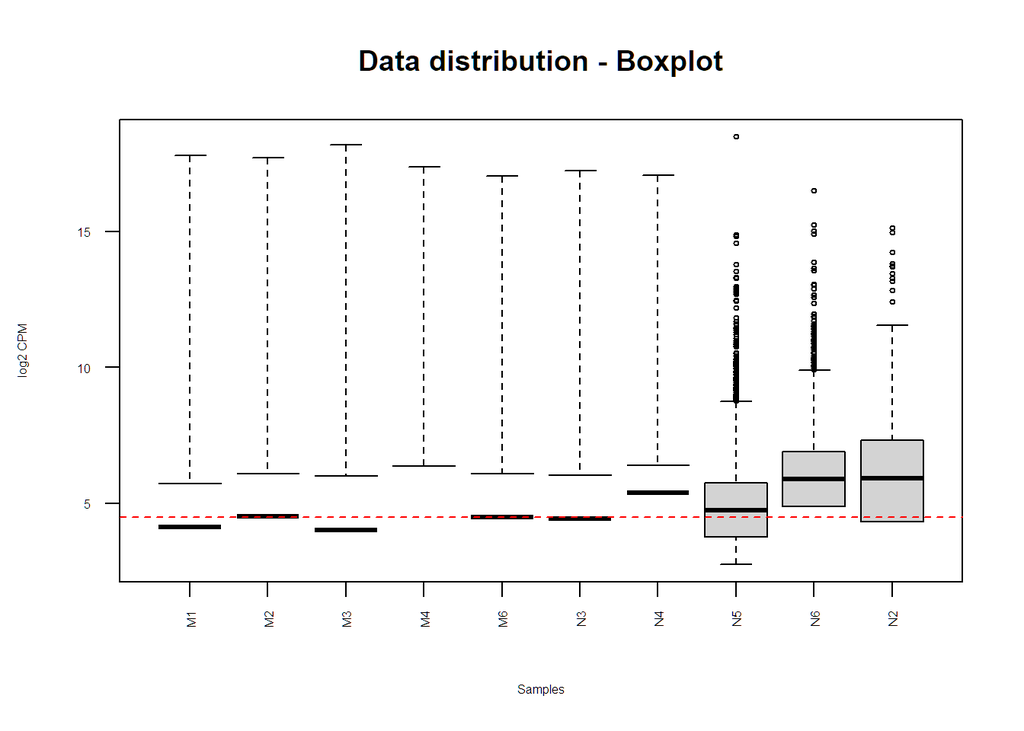

```r
data2plot <- log2(cpm(genes_filtered[,2:11]))
colnames(data2plot) <- lapply(colnames(genes_filtered)[2:11],
                              FUN=function(x) {unlist(strsplit(x,
                              split="\\_"))[c(1)]})
boxplot(data2plot, xlab = "Samples", ylab = "log2 CPM",
las = 2, cex = 0.5, cex.lab = 0.5,
cex.axis = 0.5, main = "Data distribution - Boxplot")
abline(h = median(apply(data2plot, 2, median)),
col = "red", lwd = 1.2, lty = "dashed")
```

Data distribution Density plot

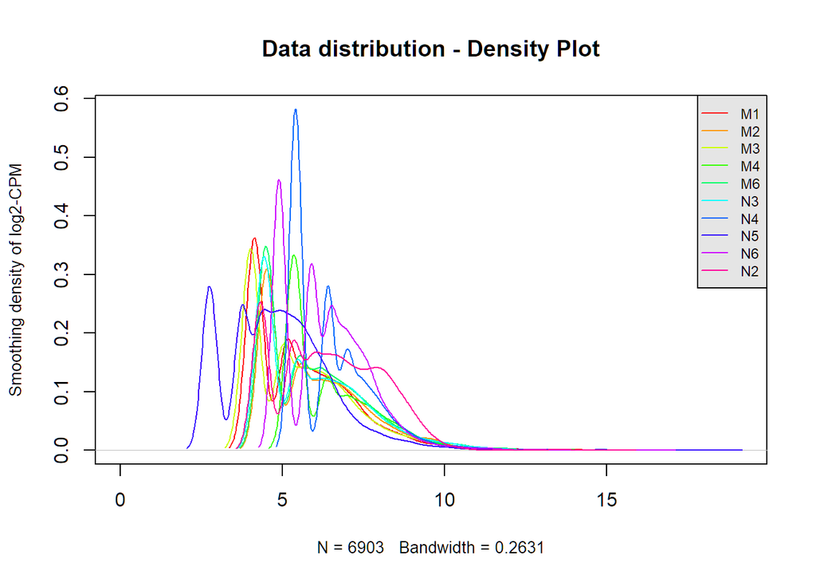

```r
counts_density <- apply(log2(cpm(genes_filtered[,2:11])),
2, density)
xlim <- 0; ylim <- 0
for (i in 1:length(counts_density)) {
xlim <- range(c(xlim, counts_density[[i]]$x));
ylim <- range(c(ylim, counts_density[[i]]$y))
}
cols <- rainbow(length(counts_density))
ltys <- rep(1, length(counts_density))
plot(counts_density[[1]], xlim=xlim, ylim=ylim, type="n",
ylab="Smoothing density of log2-CPM",
main="Data distribution - Density Plot", cex.lab = 0.85)
for (i in 1:length(counts_density))
lines(counts_density[[i]], col=cols[i], lty=ltys[i])
legend("topright", colnames(data2plot),
col=cols, lty=ltys, cex=0.75,
border ="blue", text.col = "black",
merge = TRUE, bg = "gray90")
```

MA plot for data comparing metabolic syndrome vs control groups

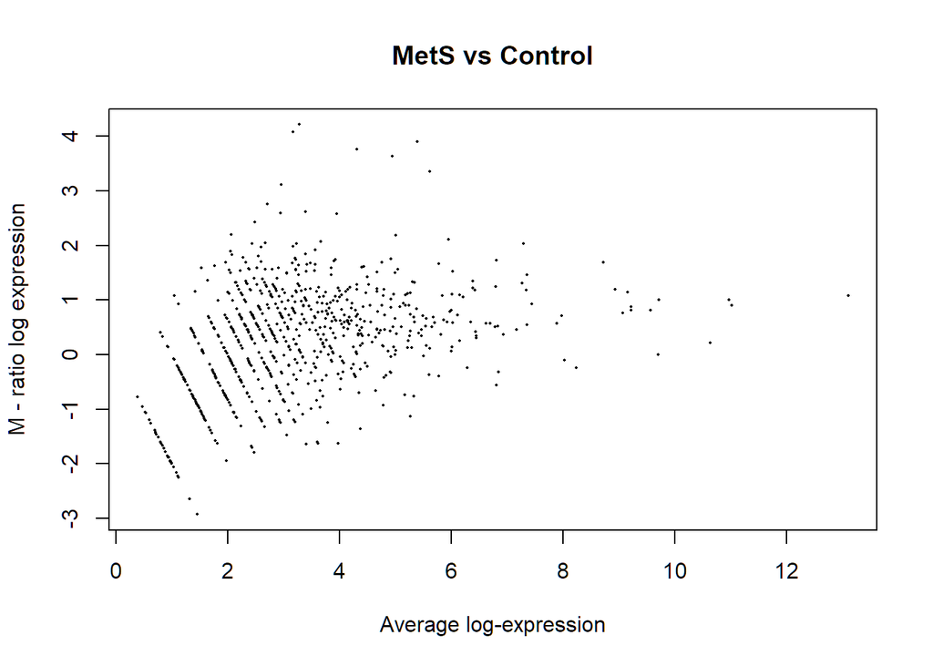

```r
plotMA(log2(genes_filtered[,c(2:6,7:11)]), ylab="M - ratio log expression",
main="MetS vs Control")
```

## Normalization

Trimmed Mean of M-values (TMM)

```r
filtered_data_matrix <- as.matrix(genes_filtered[,2:11])
rownames(filtered_data_matrix) <- genes_filtered$ensembl_id
d = DGEList(counts=filtered_data_matrix, group=samples$Status)
```

```r
d = calcNormFactors(d)
#d_NormFac = calcNormFactors(d_DGE)
```

```r
normalized_counts <- cpm(d)
#normalized_counts <- cpm(d_NormFac)
```

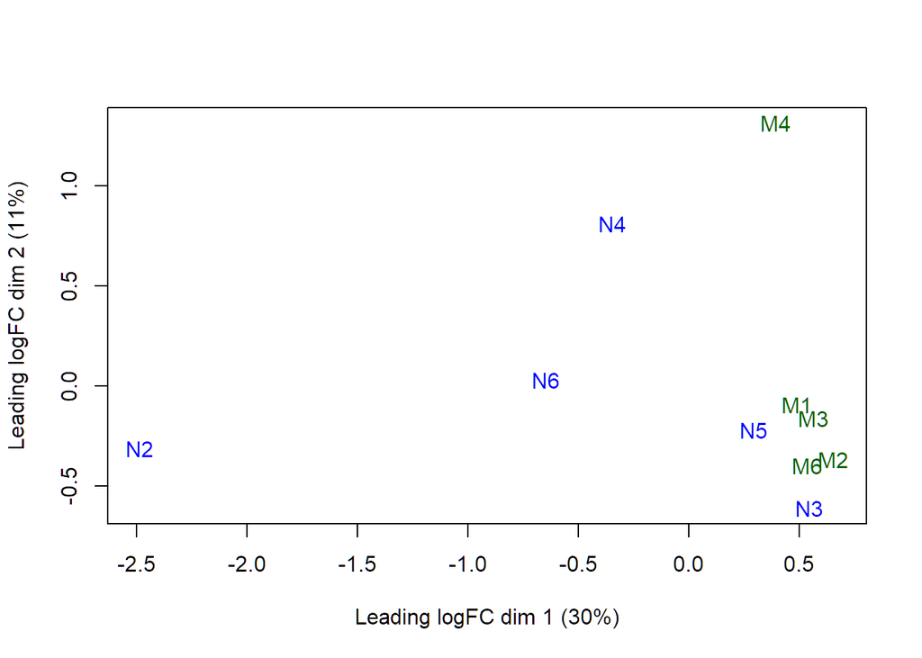

```r
plotMDS(d, labels=lapply(rownames(samples), FUN=function(x){unlist(strsplit(x,split = "\\_"))[c(1)]}), col = c("darkgreen","blue")[factor(samples$Status)])
```

```r
#plotMDS(d_NormFac, labels=lapply(rownames(samples), #FUN=function(x){unlist(strsplit(x,split = "\\_"))[c(1)]}), col = #c("darkgreen","blue")[factor(samples$Status)])
```

```r
model_design <- model.matrix(~samples$Status)
```

```r
d <- estimateDisp(d, model_design)
#d_Disp <- estimateDisp(d_NormFac, model_design)
```

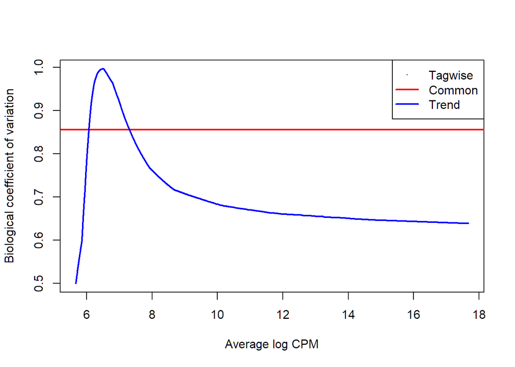

```r
plotBCV(d,col.tagwise = "black",col.common = "red",col.trend = "blue")
```

```r
#plotBCV(d_Disp,col.tagwise = "black",col.common = "red",)
```

# Mapping

```r
ensembl <- useMart("ensembl")
datasets = listDatasets(ensembl)
kable(head(datasets),format = "pipe")
```

| dataset | description | version |
| --- | --- | --- |
| abrachyrhynchus_gene_ensembl | Pink-footed goose genes (ASM259213v1) | ASM259213v1 |
| acalliptera_gene_ensembl | Eastern happy genes (fAstCal1.2) | fAstCal1.2 |
| acarolinensis_gene_ensembl | Green anole genes (AnoCar2.0v2) | AnoCar2.0v2 |
| acchrysaetos_gene_ensembl | Golden eagle genes (bAquChr1.2) | bAquChr1.2 |
| acitrinellus_gene_ensembl | Midas cichlid genes (Midas_v5) | Midas_v5 |
| amelanoleuca_gene_ensembl | Giant panda genes (ASM200744v2) | ASM200744v2 |

```r
kable(head(datasets[grep(datasets$dataset,
                         pattern = "sapiens"),]),format = "pipe")
```

|  | dataset | description | version |
| --- | --- | --- | --- |
| 79 | hsapiens_gene_ensembl | Human genes (GRCh38.p13) | GRCh38.p13 |

```r
ensembl = useDataset("hsapiens_gene_ensembl",mart=ensembl)
dim(listFilters(ensembl))
```

```
## [1] 435   2
```

```r
#ensembl = useEnsembl(biomart='ensembl', dataset=ensembl_dataset, mirror = "uswest")
```

```r
biomart_human_filters <- listFilters(ensembl)
kable(biomart_human_filters[
grep(biomart_human_filters$name,pattern="ensembl"),],
format="html") %>%
row_spec(3, background = "yellow")
```

|  | name | description |
| --- | --- | --- |
| 54 | ensembl_gene_id | Gene stable ID(s) [e.g. ENSG00000000003] |
| 55 | ensembl_gene_id_version | Gene stable ID(s) with version [e.g. ENSG00000000003.15] |
| 56 | ensembl_transcript_id | Transcript stable ID(s) [e.g. ENST00000000233] |
| 57 | ensembl_transcript_id_version | Transcript stable ID(s) with version [e.g. ENST00000000233.10] |
| 58 | ensembl_peptide_id | Protein stable ID(s) [e.g. ENSP00000000233] |
| 59 | ensembl_peptide_id_version | Protein stable ID(s) with version [e.g. ENSP00000000233.5] |
| 60 | ensembl_exon_id | Exon ID(s) [e.g. ENSE00000000001] |

```r
gene_mapped <- getBM(attributes = c("ensembl_gene_id","hgnc_symbol"),
filters = c("ensembl_gene_id"),
values = genes_filtered$ensembl_id,
mart = ensembl)
```

```r
length(which(rownames(normalized_counts) %in%
gene_mapped$ensembl_gene_id))
```

```
## [1] 6879
```

```r
nrow(normalized_counts)
```

```
## [1] 6903
```

```r
nrow(normalized_counts) - length(which(rownames(normalized_counts) %in%
gene_mapped$ensembl_gene_id))
```

```
## [1] 24
```

```r
normalized_counts_annot <- merge(gene_mapped,normalized_counts,
by.x = 1, by.y = 0, all.y=TRUE)
kable(normalized_counts_annot[1:10,c(1,2,3,8)],format = "html")
```

| ensembl_gene_id | hgnc_symbol | M1_GTTCGCTCTC_60 | N3_TACCGTTCTT_66 |
| --- | --- | --- | --- |
| ENSG00000000460 | C1orf112 | 0.00000 | 21.24641 |
| ENSG00000000938 | FGR | 67.40167 | 0.00000 |
| ENSG00000001084 | GCLC | 22.46722 | 84.98564 |
| ENSG00000001629 | ANKIB1 | 0.00000 | 0.00000 |
| ENSG00000002079 | MYH16 | 22.46722 | 42.49282 |
| ENSG00000002549 | LAP3 | 0.00000 | 0.00000 |
| ENSG00000002746 | HECW1 | 22.46722 | 42.49282 |
| ENSG00000002822 | MAD1L1 | 44.93445 | 0.00000 |
| ENSG00000002834 | LASP1 | 44.93445 | 21.24641 |
| ENSG00000003056 | M6PR | 112.33611 | 106.23206 |

```r
length(ensembl_id_missing_gene <- normalized_counts_annot$ensembl_gene_id[
which(is.na(normalized_counts_annot$hgnc_symbol))])
```

```
## [1] 24
```

**What are the control and test conditions of the dataset?** In this study, test condition includes 5 patients with metabolic syndrom, and controls include 5 healthy individuals.

**Why is the dataset of interest to you?** Metabolic syndrome is defined as a set of metabolic disturbances including but not limited to, obesity, hypertension, insulin resistance that eventually results in cardiovascular disorders, liver disease, and type 2 diabetes. Many people worldwide are suffering from this condition.<sup>20</sup>

**Were there expression values that were not unique for specific genes? How did you handle these?** In this dataset, there is not any duplicate of genes. I used duplicated function to detect any duplication.

**Were there expression values that could not be mapped to current HUGO symbols?** Yes. 24 genes are not mapped to the current HUGO symbols.

**How many outliers were removed?** 25,488 entries were removed with less than 1 read per million in the sample.

**How did you handle replicates?** Except for those with low counts, replicates in the control and test conditions have been used in the data.

**What is the final coverage of your dataset?** 21.31%; that includes 6,903 genes, 10 samples (5 metabolic syndroms, and 5 healthy individuals)

All codes in this work are adapted from lectures instructed by Dr. Ruth Isserlin<sup>21</sup>

## References

1.

Xie Y, Allaire JJ, Grolemund G. *R Markdown: The Definitive Guide*. Chapman; Hall/CRC; 2018.

2.

Allaire J, Xie Y, McPherson J, et al. Rmarkdown: Dynamic documents for r. R package version 2.20.1. 2023.

3.

Xie Y, Dervieux C, Riederer E. *R Markdown Cookbook*. Chapman; Hall/CRC; 2020.

4.

Zhu H. *kableExtra: Construct Complex Table with ’Kable’ and Pipe Syntax*.; 2021. https://CRAN.R-project.org/package=kableExtra.

5.

Müller K, Wickham H, James DA, Falcon S. *RSQLite: SQLite Interface for r*.; 2023.

6.

R Special Interest Group on Databases (R-SIG-DB), Wickham H, Müller K. *DBI: R Database Interface*.; 2022.

7.

Davis S, Meltzer P. GEOquery: A bridge between the gene expression omnibus (GEO) and BioConductor. *Bioinformatics*. 2007;14:1846-1847.

8.

Morgan M. *BiocManager: Access the Bioconductor Project Package Repository*.; 2022. https://CRAN.R-project.org/package=BiocManager.

9.

Zhu Y, Davis S, Stephens R, Meltzer PS, Chen Y. GEOmetadb: Powerful alternative search engine for the gene expression omnibus. *Bioinformatics*. 2008;24(23):2798-2800.

10.

Durinck S, Spellman PT, Birney E, Huber W. Mapping identifiers for the integration of genomic datasets with the r/bioconductor package biomaRt. *Nature protocols*. 2009;4(8):1184-1191.

11.

Durinck S, Moreau Y, Kasprzyk A, et al. BioMart and bioconductor: A powerful link between biological databases and microarray data analysis. *Bioinformatics*. 2005;21(16):3439-3440.

12.

Drost H-G, Paszkowski J. Biomartr: Genomic data retrieval with r. *Bioinformatics*. 2017;33(8):1216-1217.

13.

Loraine AE, Blakley IC, Jagadeesan S, Harper J, Miller G, Firon N. Analysis and visualization of RNA-seq expression data using RStudio, bioconductor, and integrated genome browser. *Plant Functional Genomics: Methods and Protocols*. 2015:481-501.

14.

Robinson MD, McCarthy DJ, Smyth GK. edgeR: A bioconductor package for differential expression analysis of digital gene expression data. *bioinformatics*. 2010;26(1):139-140.

15.

Wickham H, Hester J, Chang W, Bryan J. *Devtools: Tools to Make Developing r Packages Easier*.; 2022.

16.

Dervieux C. *Pandoc: Manage and Run Universal Converter ’Pandoc’ from ’r’*.; 2022.

17.

Xie Y. *Knitr: A General-Purpose Package for Dynamic Report Generation in r*.; 2023. https://yihui.org/knitr/.

18.

Xie Y. *Dynamic Documents with R and Knitr*. 2nd ed. Boca Raton, Florida: Chapman; Hall/CRC; 2015. https://yihui.org/knitr/.

19.

Xie Y. Knitr: A comprehensive tool for reproducible research in R. In: Stodden V, Leisch F, Peng RD, eds. *Implementing Reproducible Computational Research*. Chapman; Hall/CRC; 2014.

20.

Li Y, Meng Y, Liu Y, Van Wijnen AJ, Eirin A, Lerman LO. Differentially expressed functional LncRNAs in human subjects with metabolic syndrome reflect a competing endogenous RNA network in circulating extracellular vesicles. *Frontiers in molecular biosciences*. 2021;8:667056.

21.

Isserlin R. BCB420, lectures 1 to 5. 2023.